# Breast Cancer Tumor Diagnosis - Model Neural Network dengan Optimisasi Genetic Algorithm

1. (Genetic Algorithm) William Handi Wijaya - 05111940000087
2. (Neural Network) Reyhan Naufal Rahman - 05111940000171

Dataset yang kami gunakan adalah `Breast Cancer Wisconsin (Diagnostic) Data Set`. Pada dataset ini terdapat 569 pasien dengan tumor payudara. Beberapa pengukuran dan diagnosis kanker ganas dan kanker jinak tersedia untuk setiap pasien.

Neural network adalah sebuah kumpulan algoritma yang dimodelkan berdasarkan otak manusia dan didesain untuk mengenali pola. Neural network menginterpretasi data sensorik berdasarkan sebuah kumpulan data yang disebut dataset. Neural network digunakan untuk melakukan pengelompokan ataupun klasifikasi data.

Genetic algorithm adalah sebuah algoritma untuk menyelesaikan masalah mengoptimasi berdasarkan proses seleksi natural yang menirukan evolusi biologis. Genetic algorithm digunakan untuk mengoptimasi sesuatu.

Kami berencana untuk mengoptimasi neural network menggunakan feature selection dengan algoritma genetic algorithm. Dengan melakukan feature selection, jumlah fitur yang digunakan oleh model akan semakin sedikit karena fitur yang menyesatkan tidak akan terseleksi pada feature selection. Akibatnya, model neural network akan mengurangi sumber daya komputasi yang digunakan, waktu mempercepat waktu pelatihan dan prediksi, serta meningkatkan tingkat akurasi model.

Tujuan dari model neural network ini adalah untuk memprediksi penyakit kanker payudara.

## Informasi Atribut

1) ID number  
2) Diagnosis (M = malignant (ganas), B = benign (jinak) )

3-32) Terdapat 10 fitur yang dihitung untuk masing-masing pasien.  
a) radius (rerata jarak dari tengah ke garis keliling)  
b) texture (deviasi standar dari nilai gray-scale)  
c) perimeter  
d) area  
e) smoothness (variasi lokal dalam panjang radius)  
f) compactness (perimeter^2 / area - 1.0)  
g) concavity (tingkat keparahan bagian cekung dari kontur)  
h) concave points (jumlah bagian cekung dari kontur)  
i) symmetry  
j) fractal dimension ("perkiraan coastline" - 1)

Rerata, nilai standard error, dan nilai terburuk dari masing-masing pengukuran fitur di atas telah tersedia pada dataset, sehingga didapatkan 30 fitur. Contohnya, kolom 3 adalah rerata radius (*mean radius*), kolom 13 adalah standard error dari radius (*radius se*), dan kolom 23 adalah radius terburuk (*worst radius*).

Semua fitur ditampilkan dengan 4 digit signifikan.

Distribusi kelas: 357 jinak (benign), 212 ganas (malignant)

## Refrensi Dataset

Dataset ini didapat dari, William H, Nick S, dan Olvi L. (1995). UCI Machine Learning Repository. Irvine (http://archive.ics.uci.edu/ml), CA: University of California, School of Information and Computer Science.

[Breast Cancer Wisconsin (Diagnostic) Data Set](https://intip.in/Drm0)

## 1. Ekspor dan Evaluasi Data

```python
import numpy as np
import pandas as pd
import matplotlib.pyplot as plt
```

```python
dataset=pd.read_csv("UCI Breast Cancer Wisconsin.csv")
```

```python
dataset.head()
```

|  | id | diagnosis | radius_mean | texture_mean | perimeter_mean | area_mean | smoothness_mean | compactness_mean | concavity_mean | concave points_mean | ... | texture_worst | perimeter_worst | area_worst | smoothness_worst | compactness_worst | concavity_worst | concave points_worst | symmetry_worst | fractal_dimension_worst | Unnamed: 32 |
| --- | --- | --- | --- | --- | --- | --- | --- | --- | --- | --- | --- | --- | --- | --- | --- | --- | --- | --- | --- | --- | --- |
| 0 | 842302 | M | 17.99 | 10.38 | 122.80 | 1001.0 | 0.11840 | 0.27760 | 0.3001 | 0.14710 | ... | 17.33 | 184.60 | 2019.0 | 0.1622 | 0.6656 | 0.7119 | 0.2654 | 0.4601 | 0.11890 | NaN |
| 1 | 842517 | M | 20.57 | 17.77 | 132.90 | 1326.0 | 0.08474 | 0.07864 | 0.0869 | 0.07017 | ... | 23.41 | 158.80 | 1956.0 | 0.1238 | 0.1866 | 0.2416 | 0.1860 | 0.2750 | 0.08902 | NaN |
| 2 | 84300903 | M | 19.69 | 21.25 | 130.00 | 1203.0 | 0.10960 | 0.15990 | 0.1974 | 0.12790 | ... | 25.53 | 152.50 | 1709.0 | 0.1444 | 0.4245 | 0.4504 | 0.2430 | 0.3613 | 0.08758 | NaN |
| 3 | 84348301 | M | 11.42 | 20.38 | 77.58 | 386.1 | 0.14250 | 0.28390 | 0.2414 | 0.10520 | ... | 26.50 | 98.87 | 567.7 | 0.2098 | 0.8663 | 0.6869 | 0.2575 | 0.6638 | 0.17300 | NaN |
| 4 | 84358402 | M | 20.29 | 14.34 | 135.10 | 1297.0 | 0.10030 | 0.13280 | 0.1980 | 0.10430 | ... | 16.67 | 152.20 | 1575.0 | 0.1374 | 0.2050 | 0.4000 | 0.1625 | 0.2364 | 0.07678 | NaN |

5 rows × 33 columns

```python
# (baris, kolom)
dataset.shape
```

```
(569, 33)
```

```python
# Menampilkan kolom-kolom yang terdapat pada dataset beserta tipe datanya.
dataset.dtypes
```

```
id                           int64
diagnosis                   object
radius_mean                float64
texture_mean               float64
perimeter_mean             float64
area_mean                  float64
smoothness_mean            float64
compactness_mean           float64
concavity_mean             float64
concave points_mean        float64
symmetry_mean              float64
fractal_dimension_mean     float64
radius_se                  float64
texture_se                 float64
perimeter_se               float64
area_se                    float64
smoothness_se              float64
compactness_se             float64
concavity_se               float64
concave points_se          float64
symmetry_se                float64
fractal_dimension_se       float64
radius_worst               float64
texture_worst              float64
perimeter_worst            float64
area_worst                 float64
smoothness_worst           float64
compactness_worst          float64
concavity_worst            float64
concave points_worst       float64
symmetry_worst             float64
fractal_dimension_worst    float64
Unnamed: 32                float64
dtype: object
```

```python
# Menampilkan jumlah pasien berdasarkan tipe diagnosisnya
dataset['diagnosis'].value_counts()
```

```
B    357
M    212
Name: diagnosis, dtype: int64
```

Berdasarkan pemaparan di atas, didapatkan beberapa informasi mengenai dataset ini.

## 2. Feature Preprocessing

Langkah-langkah berikut merupakan perisapan untuk data neural network:

```python
d = {'M':1,'B':0}
dataset = dataset.replace(d)
label = dataset["diagnosis"]
dataset.drop(["id","diagnosis","Unnamed: 32"],axis=1, inplace=True)
```

Setelah kolom id dan kolom yang kosong dihapus, maka grafik persebaran nilai pada masing-masing fitur bisa ditampilkan.

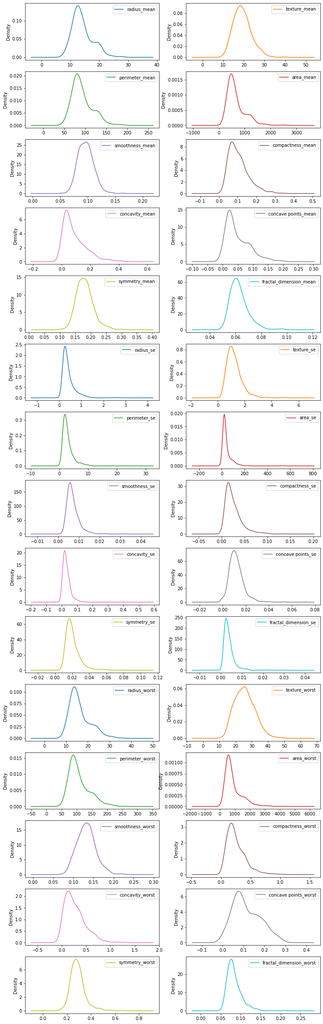

```python
dataset.plot(kind='density',subplots=True,layout=(16,2),figsize=(12,45),sharex=False)
plt.show()
```

Grafik persebaran diagnosis adalah sebagai berikut, dimana 1 melambangkan ganas (**M** atau **malignant**) dan 0 melambangkan jinak (**B** atau **benign**).

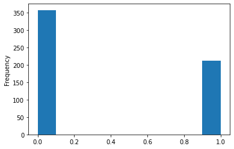

```python
label.plot(kind='hist')
```

Setelah dilakukan *preprocessing*, isi dataset akan menjadi seperti berikut:

```python
dataset.head()
```

|  | radius_mean | texture_mean | perimeter_mean | area_mean | smoothness_mean | compactness_mean | concavity_mean | concave points_mean | symmetry_mean | fractal_dimension_mean | ... | radius_worst | texture_worst | perimeter_worst | area_worst | smoothness_worst | compactness_worst | concavity_worst | concave points_worst | symmetry_worst | fractal_dimension_worst |
| --- | --- | --- | --- | --- | --- | --- | --- | --- | --- | --- | --- | --- | --- | --- | --- | --- | --- | --- | --- | --- | --- |
| 0 | 17.99 | 10.38 | 122.80 | 1001.0 | 0.11840 | 0.27760 | 0.3001 | 0.14710 | 0.2419 | 0.07871 | ... | 25.38 | 17.33 | 184.60 | 2019.0 | 0.1622 | 0.6656 | 0.7119 | 0.2654 | 0.4601 | 0.11890 |
| 1 | 20.57 | 17.77 | 132.90 | 1326.0 | 0.08474 | 0.07864 | 0.0869 | 0.07017 | 0.1812 | 0.05667 | ... | 24.99 | 23.41 | 158.80 | 1956.0 | 0.1238 | 0.1866 | 0.2416 | 0.1860 | 0.2750 | 0.08902 |
| 2 | 19.69 | 21.25 | 130.00 | 1203.0 | 0.10960 | 0.15990 | 0.1974 | 0.12790 | 0.2069 | 0.05999 | ... | 23.57 | 25.53 | 152.50 | 1709.0 | 0.1444 | 0.4245 | 0.4504 | 0.2430 | 0.3613 | 0.08758 |
| 3 | 11.42 | 20.38 | 77.58 | 386.1 | 0.14250 | 0.28390 | 0.2414 | 0.10520 | 0.2597 | 0.09744 | ... | 14.91 | 26.50 | 98.87 | 567.7 | 0.2098 | 0.8663 | 0.6869 | 0.2575 | 0.6638 | 0.17300 |
| 4 | 20.29 | 14.34 | 135.10 | 1297.0 | 0.10030 | 0.13280 | 0.1980 | 0.10430 | 0.1809 | 0.05883 | ... | 22.54 | 16.67 | 152.20 | 1575.0 | 0.1374 | 0.2050 | 0.4000 | 0.1625 | 0.2364 | 0.07678 |

5 rows × 30 columns

```python
# Buat Numpy array dari matriks fitur yang akan digunakan pada neural network
X = np.array(dataset).T

 #Buat Numpy array dari array diagnosis yang akan digunakan pada neural network
Y = np.array(label).T
Y = Y.reshape(1,569)
```

```python
# Normalisasikan matriks fitur
X_mean = np.mean(X,axis=1,keepdims=True)
X_max = np.max(X,axis=1,keepdims=True)
X_normalized = (X-X_mean)/(X_max)
```

## 3. Metode

Metode akan terdiri dari dua tahap, yaitu:

[figure not shown]

### 1. Feature Selection

Pada populasi di genetic algorithm, populasi tersebut akan terdiri dari kromosom-kromosom, dimana gen-gen pada setiap kromosom merepresentasikan fitur yang diseleksi. Sebuah gen dapat bernilai 1 atau 0. Gen yang bernilai 1 merepresentasikan fitur yang diseleksi pada indeks tersebut, sedangkan gen yang bernilai 0 merepresentasikan hal sebaliknya.

[figure not shown]

Berikut ini algoritma pada feature selection menggunakan genetic algorithm:

1. Tentukan *classifier* yang akan digunakan untuk menentukan *fitness score* pada kromosom.
2. Inisialisasikan populasi secara acak.
3. Evaluasi tingkat *fitness* dari tiap kromosom pada populasi saat ini.
4. Jika tingkat *fitness* sudah cukup baik (sama dengan 1), hentikan program.
5. Ambil n buah kromosom terbaik, dimana n adalah sebuah parameter.
6. Lakukan *crossover* pada setiap kromosom dari hasil pada langkah 5.
7. Mutasikan setiap kromosom dari hasil pada langkah 6.
8. Tetapkan hasil dari nomor 6 sebagai populasi baru untuk generasi selanjutnya.
9. Ulangi langkah 2-8 sebanyak x kali, dimana x adalah sebuah parameter yang menandakan jumlah generasi.
10. Tampilkan fitur-fitur yang diseleksi pada kromosom dengan *fitness_score* tertinggi.

### 2. Training

Data yang ada akan dibagi menjadi dua yaitu test_set dan cross validation set. Training set akan menggunakan data 380 pasien pertama (66,67%), dan cross validation set akan menggunakan data 188 pasien sisanya. Neural network yang kami buat akan dilatih pada training set dan akurasinya akan divalidasi oleh cross-validation set.

Berikut merupakan struktur neural network yang kami buat:

- Neural network akan mempunyai satu input layer, dua hidden layers dan satu output layer.
- Hidden layer 1 akan mempunyai 3 node, dan hidden layer 2 akan mempunyai 2 node.
- Hidden layer 1 dan 2 akan menggunakan fungsi aktivasi tanh(x), dan output layer 2 akan menggunakan fungsi aktivasi sigmoid.

Representasi Neural Network

[figure not shown]

**Layer 1**

- Z1 = W1.T x X dimana w1 mewakili matriks bobot di layer pertama dan x mewakili matriks fitur kami
- A1 = tanh(Z1 + b1) dimana b1 mewakili istilah intercept kami untuk lapisan pertama

**Layer 2**

- Z2 = W2.T x A1 dimana W2 mewakili matrix bobot di L2
- A2 = tanh(Z2 + b2) dimana b2 mewakili intercept kami untuk lapisan kedua

**Layer 3**

## 4. Implementasi Algoritma Genetika

### Import library yang dibutuhkan

Pada implementasi algoritma genetika ini, library yang dibutuhkan adalah:

- `sys`
- `numpy`
- `matplotlib`
- `sklearn`
- `pandas`
- `seaborn`
- `random`

```python
import sys
import numpy as np
import pandas as pd
import seaborn as sns
import matplotlib.pyplot as plt
import random
from random import randint
%matplotlib inline
import warnings
warnings.filterwarnings("ignore")

from sklearn.model_selection import train_test_split
from sklearn import svm
from sklearn.linear_model import LogisticRegression
from sklearn.ensemble import RandomForestClassifier, AdaBoostClassifier
from sklearn.tree import DecisionTreeClassifier
from sklearn.neighbors import KNeighborsClassifier
from sklearn.ensemble import GradientBoostingClassifier
from sklearn import metrics
from sklearn.metrics import accuracy_score
from sklearn.model_selection import KFold, cross_val_score
```

### Definisi fungsi-fungsi bantuan

1. **split()**  
   Mengembalikan 4 variable yaitu `X_train` , `X_test`, `y_train`, `y_test`. Pada dasarnya fungsi ini memecah dataset menjadi training dan test set.
2. **plot()**  
   Mem-plotting hasil kedalam grafik *pointplot*.
3. **get_feature()**  
   Mendapatkan jumlah *features* beserta nama-nama *features* yang diseleksi pada sebuah kromosom.
4. **show_chromosome()**  
   Menampilkan *features* pada sebuah kromosom.
5. **show_chromosomes()**  
   Menampilkan *features* pada suatu list kromosom.
6. **get_best_chromo()**  
   Mendapatkan kromosom dengan tingkat akurasi tertinggi dan jumlah fitur terendah.

```python
def split(dataset, label, train_amount):
    X_train = X_normalized[:,:train_amount]
    Y_train = Y[:,:train_amount]

    X_test = X_normalized[:,train_amount+1:]
    Y_test = Y[:,train_amount+1:]
    return X_train, X_test, Y_train, Y_test


def plot(score,x,y,c = "b"):
    gen = [i for i in range(1,len(score)+1)]
    plt.figure(figsize=(6,4))
    ax = sns.pointplot(x=gen, y=score,color = c )
    ax.set(xlabel="Generation", ylabel="Accuracy")
    ax.set(ylim=(x,y))


def get_feature(chromosome):
    count = 0
    features = []
    for feature in dataset.iloc[:,chromosome].columns:
        count += 1
        features.append(feature)
    return [count, ', '.join(features)]


def show_chromosome(chromosome):
    [count, features] = get_feature(chromosome)
    print("Features:\n" + features, end='')
    print("\nTotal: " + str(count) + " features\n")


def show_chromosomes(chromosomes):
    i = 0
    for chromosome in chromosomes:
        print('Generation ' + str(i + 1))
        show_chromosome(chromosome)
        i += 1


def get_best_chromo(best_chromos, best_scores):
    highest_score = np.amax(best_scores)
    indices = np.where(np.array(best_scores) == highest_score)[0].tolist()

    min_count = sys.maxsize
    best_chromo = None

    for i in indices:
        chromosome = best_chromos[i]
        [count, features] = get_feature(chromosome)
        if count < min_count:
            min_count = count
            best_chromo = chromosome
    return best_chromo
```

### Definisi fungsi-fungsi untuk Algoritma Genetika

1. **initilization_of_population()**  
   Membuat sebuah populasi baru secara random.
2. **fitness_score()**  
   Menghitung nilai *fitness* dari setiap kromosom *parent* dalam populasi, dimana nilai *score* akan dibulatkan hingga 9 desimal.
3. **selection()**  
   Seleksi (pemilihan) kromosom terbaik.
4. **crossover()**  
   Crossover dilakukaan menggunakan *Uniform Crossover*, dimana tiap gen yang diturunkan kepada *child chromosome* diambil dari salah satu *parent* secara acak. Hal ini dilakukan sebagai mitigasi terjadinya *premature convergence*.
5. **mutation()**  
   Secara random menegasikan bit dari *child* hasil *crossover*.
6. **generations()**  
   Mengeksekusi semua fungsi di atas untuk jumlah generasi tertentu.

```python
def initilization_of_population(size,n_feat):
    population = []
    for i in range(size):
        chromosome = np.ones(n_feat,dtype=np.bool)
        chromosome[:int(0.3*n_feat)]=False
        np.random.shuffle(chromosome)
        population.append(chromosome)
    return population


def fitness_score(population):
    scores = []
    for chromosome in population:
        indices = np.nonzero(chromosome)
        predictions = predict(X_train[indices],Y_train,1000,0.5,X_train[indices],Y_train)
        accuracy = get_accuracy(Y_train[0], predictions[0]) / 100
        scores.append(round(accuracy, 9))
    scores, population = np.array(scores), np.array(population)
    inds = np.argsort(scores)
    return list(scores[inds][::-1]), list(population[inds,:][::-1])


def selection(pop_after_fit,n_parents):
    population_nextgen = []
    for i in range(n_parents):
        population_nextgen.append(pop_after_fit[i])
    return population_nextgen


def crossover(pop_after_sel):
    pop_nextgen = pop_after_sel
    for i in range(0,len(pop_after_sel),2):
        child = []
        parent_1, parent_2 = pop_nextgen[i], pop_nextgen[i+1]
        gen_amount = len(parent_1)

        for i in range(gen_amount):
            gen = random.choice([parent_1[i], parent_2[i]])
            child.append(gen)

        pop_nextgen.append(child)
    return pop_nextgen


def mutation(pop_after_cross,mutation_rate,n_feat):
    mutation_range = int(mutation_rate*n_feat)
    pop_next_gen = []
    for n in range(0,len(pop_after_cross)):
        chromo = pop_after_cross[n]
        rand_posi = []
        for i in range(0,mutation_range):
            pos = randint(0,n_feat-1)
            rand_posi.append(pos)
        for j in rand_posi:
            chromo[j] = not chromo[j]
        pop_next_gen.append(chromo)
    return pop_next_gen


def generations(df,label,size,n_feat,n_parents,mutation_rate,n_gen,X_train,
                                   X_test, Y_train, Y_test):
    best_chromos= []
    best_scores= []
    population_nextgen=initilization_of_population(size,n_feat)
    for i in range(n_gen):
        scores, pop_after_fit = fitness_score(population_nextgen)
        print('Best score in generation ' + str(i+1).zfill(2) + ' : ' + str(scores[0]))
        best_chromos.append(pop_after_fit[0])
        best_scores.append(scores[0])

        if (scores[0] == 1):
            break

        pop_after_sel = selection(pop_after_fit,n_parents)
        pop_after_cross = crossover(pop_after_sel)
        population_nextgen = mutation(pop_after_cross,mutation_rate,n_feat)
    return best_chromos,best_scores
```

## 5. Implementasi Neural Network

Berikut merupakan struktur neural network yang kami buat:

Representasi neural network:

[figure not shown]

## Fungsi Aktivasi

```python
def sigmoid(z):
    s = 1/(1+np.exp(-z))
    return s

def tanh(z):
    s = (np.exp(z) - np.exp(-z)) / (np.exp(z) + np.exp(-z))
    return s
```

Setelah mendefinisikan fungsi aktivasi, selanjutnya adalah mendefinisikan algoritma forward propogation.

Untuk mengoptimalkan kode, kami menggunakan implementasi forward propogation. Untuk melakukannya, rumus berikut akan digunakan:

*Note: x means matrix multiplication*

**Layer 1**

- `Z1 = W1.T x X` dimana `w1` meewakili matriks bobot di layer pertama dan `x` mewakili matriks fitur kami
- `A1 = tanh(Z1 + b1)` dimana `b1` mewakili istilah intercept kami untuk lapisan pertama

**Layer 2**

- `Z2 = W2.T x A1` dimana `W2` mewakili matrix bobot di L2
- `A2 = tanh(Z2 + b2)` dimana `b2` mewakili intercept kami untuk lapisan kedua

**Layer 3**

```python
def forward_prop(X,W1,W2,W3,b1,b2,b3):

    # Layer Pertama
    Z1 = np.dot(W1,X)
    A1 = tanh(Z1 + b1)
    # Layer Kedua
    Z2 = np.dot(W2,A1)
    A2 = tanh(Z2 + b2)
    # Layer Ketiga
    Z3 = np.dot(W3,A2)
    A3 = sigmoid(Z3 + b3) # A3 akan menghasilkan vektor probabilitas

    cache = {
          "Z1": Z1,
          "A1": A1,
          "Z2": Z2,
          "A2": A2,
          "Z3": Z3,
          "A3": A3
    }
    return cache
```

Setelah mendefinisikan fungsi forward propogation, selanjutnya adalah mendefinisikan algoritma backpropogation dan gradient descent. Langkah-langkah berikut akan dilakukan untuk melakukan gradient descents, dan menentukan nilai bobot yang optimal disetiap layer

1. Mulailah dengan menginisialisasi parameter bobot dan intercept secara acak
2. Jalankan forward propogation melalui jaringan saraf
3. Hitung turunan dari bobot parameter intersep melalui back propogation
4. Perbaiki parameter menggunakan turunan dari (3)
5. Ulangi 1 - 4 x kali

Rumus const function:

> `cost = -(1 / m)*np.sum(np.multiply(Y,np.log(A3)) + np.multiply((1-Y),np.log(1-A3)))`

> Dimana m merupakan nilai jumlah data training yang kami gunakan.

> *Ini merupakan cost function yang sering digunakan ketika output layer menggunakan fungsi sigmoid*

Rumus berikut akan digunakan untuk menghitung turunan bobot untuk setiap layers

> `dZ[l] = dA[l] * g'[l]{Z[l]} where g'[l]{Z[l]}` adalah turunan dari fungsi aktivasi pada layer l, dievaluasi pada `Z[l]`

> `dA[l-1] = W[l].T x dZ[l]`

> Maka,

> **`dW[l] = (1 / m)*dZ[l] x A[l-1].T`**

> dan

> **`db[l] =(1 / m) * column sum of dZ[l]`**

Parameter kami akan diperbarui menggunakan rumus berikut setelah setiap iterasi untuk membawa cost function lebih dekat ke minimum globalnya:

alpha = 'learning rate' hyperparameter

> `W1 := W1 - alpha*dW1`

> `W2 := W2 - alpha*'W2`

> `W3 := W3 - alpha*W3`

> `b1 := b1 - alpha*b1`

> `b2 := b2 - alpha*db2`

> `b3 := b3 - alpha*db3`

Setelah setiap pembaruan parameter, kami akan menjalankan kembali forward propogation dan menghitung cost function. Kami kemudian akan menyimpannya dalam array sehingga kami dapat menggunakannya dalam analisis kinerja model kami nanti.

```python
# 1. Menginisialisasi parameter bobot dan intercept secara acak
# 2. Jalankan forward propogation melalui jaringan saraf
# 3. Hitung turunan dari bobot parameter intersep melalui back propogation
# 4. Perbaiki parameter menggunakan turunan dari (3)
# 5. Ulangi 1 - 4 x kali


def gradient_descent(iterations,X,Y,alpha):

    #Randomly initialized our parameters before running the algorithm
    W1 = np.random.randn(3,X.shape[0])*0.01
    b1 = np.random.rand(3,1)
    W2 = np.random.randn(2,3)*0.01
    b2 = np.random.rand(2,1)
    W3 = np.random.rand(1,2)*0.01
    b3 = np.random.rand(1,1)
    dummy,m = X.shape

    caches = [] #penyimpanan cost untuk setiap iterasi
    count_vector = [] #penyimpanan jumlah iterasi
    count = 0

    for i in range (1,iterations):

            count = count + 1

            count_vector.append(count)

            params = forward_prop(X,W1,W2,W3,b1,b2,b3) #forward propogation

            #Tentukan nilai untuk digunakan dalam back propogation menggunakan kamus nilai yang dibuat dari  forward_prop
            Z1 = params['Z1']
            Z2 = params['Z2']
            Z3 = params['Z3']
            A1 = params['A1']
            A2 = params['A2']
            A3 = params['A3']

            #const function append setiap cost untuk setiap iterasi
            cost = -(1 / m)*np.sum(np.multiply(Y,np.log(A3)) + np.multiply((1-Y),np.log(1-A3)))
            caches.append(cost)

            #Back propogation for layer 3
            dA3 = -Y/A3 + (1-Y)/(1-A3)
            dZ3 = dA3 * sigmoid(Z3)*(1-sigmoid(Z3))
            dW3 = (1 / m)*np.dot(dZ3,A2.T)
            db3 = (1 / m)*np.sum(dZ3,axis=1,keepdims=True)

            #Back propogation for layer 2
            dA2 = np.dot(W3.T,dZ3)
            dZ2 = dA2*(1-np.power(tanh(Z2),2))
            dW2 = (1 / m)*np.dot(dZ2,A1.T)
            db2 = (1 / m)*np.sum(dZ2,axis=1,keepdims=True)

            #Back propogation for layer 1
            dA1 = np.dot(W2.T,dZ2)
            dZ1 = dA1*(1-np.power(tanh(Z1),2))
            dW1 = (1 / m)*np.dot(dZ1,X.T)
            db1 = (1 / m)*np.sum(dZ1,axis=1,keepdims=True)

            #Redefine our weight parameters using the derivatives calculated in back propogation
            W1 = W1 - alpha*dW1
            W2 = W2 - alpha*dW2
            W3 = W3 - alpha*dW3

            #Redefine our weight parameters using the derivatives calculated in back propogation
            b1 = b1 - alpha*db1
            b2 = b2 - alpha*db2
            b3 = b3 - alpha*db3

    return W1,W2,W3,b1,b2,b3,count_vector,caches
```

```python
def predict(X,Y,iterations,alpha,X_train,Y_train):

    W1,W2,W3,b1,b2,b3,count,caches = gradient_descent(iterations,X_train,Y_train,alpha)

    Z1 = np.dot(W1,X)
    A1 = tanh(Z1 + b1)
    Z2 = np.dot(W2,A1)
    A2 = tanh(Z2 + b2)
    Z3 = np.dot(W3,A2)
    A3 = sigmoid(Z3 + b3)

    dummy,m = A3.shape
    Y_prediction = np.zeros((1, m))

    for i in range(m):
        Y_prediction[0, i] = 1 if A3[0, i] > 0.5 else 0

    return Y_prediction
```

Selain itu, akan dibuat 2 fungsi untuk mengukur peforma dari *neural network* ini menggunakan *confusion matrix* dan kurva *Receiver Operating Characteristic* (ROC).

```python
from sklearn import metrics
from sklearn.metrics import confusion_matrix
import seaborn as sns

def plot_confusion_matrix(test_labels, target_predicted):
    matrix = confusion_matrix(test_labels, target_predicted)
    df_confusion = pd.DataFrame(matrix)
    colormap = sns.color_palette("BrBG", 10)
    sns.heatmap(df_confusion, annot=True, fmt='.2f', cbar=None, cmap=colormap)
    plt.title("Confusion Matrix")
    plt.tight_layout()
    plt.ylabel("True Class")
    plt.xlabel("Predicted Class")
    plt.show()

def get_accuracy(test_labels, target_predicted):
    TN, FP, FN, TP = confusion_matrix(test_labels, target_predicted).ravel()
    return float(TP+TN)/(TP+FP+FN+TN)*100

def plot_roc(test_labels, target_predicted):
    TN, FP, FN, TP = confusion_matrix(test_labels, target_predicted).ravel()
    # Sensitivity, hit rate, recall, or true positive rate
    Sensitivity  = float(TP)/(TP+FN)*100
    # Specificity or true negative rate
    Specificity  = float(TN)/(TN+FP)*100
    # Precision or positive predictive value
    Precision = float(TP)/(TP+FP)*100
    # Negative predictive value
    NPV = float(TN)/(TN+FN)*100
    # Fall out or false positive rate
    FPR = float(FP)/(FP+TN)*100
    # False negative rate
    FNR = float(FN)/(TP+FN)*100
    # False discovery rate
    FDR = float(FP)/(TP+FP)*100
    # Overall accuracy
    ACC = float(TP+TN)/(TP+FP+FN+TN)*100

    print("Sensitivity or TPR       : ",Sensitivity, "%")
    print("Specificity or TNR       : ",Specificity, "%")
    print("Precision                : ",Precision, "%")
    print("Negative Predictive Value: ",NPV, "%")
    print("False Positive Rate      : ",FPR,"%")
    print("False Negative Rate      : ",FNR, "%")
    print("False Discovery Rate     : ",FDR, "%" )
    print("Accuracy                 : ",ACC, "%")
    print("AUC                      : ",metrics.roc_auc_score(test_labels, target_predicted))

    fpr, tpr, thresholds = metrics.roc_curve(test_labels, target_predicted)
    roc_auc = metrics.auc(fpr, tpr)

    plt.figure()
    plt.plot(fpr, tpr, label='ROC curve (area = %0.2f)' % (roc_auc))
    plt.plot([0, 1], [0, 1], 'k--')
    plt.xlim([0.0, 1.0])
    plt.ylim([0.0, 1.05])
    plt.xlabel('False Positive Rate')
    plt.ylabel('True Positive Rate')
    plt.title('Receiver operating characteristic')
    plt.legend(loc="lower right")

    # create the axis of thresholds (scores)
    ax2 = plt.gca().twinx()
    ax2.plot(fpr, thresholds, markeredgecolor='r',linestyle='dashed', color='r')
    ax2.set_ylabel('Threshold',color='r')
    ax2.set_ylim([thresholds[-1],thresholds[0]])
    ax2.set_xlim([fpr[0],fpr[-1]])

    print(plt.figure())
```

Selanjutnya, statistik dari performa *neural network* ini akan diukur menggunakan dua dataset, yaitu dataset training dan dataset validasi silang. Performa yang akan diukur dalam beberapa metrik, yaitu:

1. **Sensitivity**  
   Dapat disebut juga sebagai *hit rate*, *recall*, atau *true positive rate* (TPR).  
   Metrik ini mengukur rasio true positive.
2. **Specificity**  
   Dapat disebut juga sebagai *true negative rate* (TNR). Metrik ini mengukur rasio true negative.
3. **Precision**  
   Dapat disebut juga sebagai *positive predictive value* (PPR).  
   Metrik ini menyatakan rasio neural network untuk memprediksi suatu baris sebagai "M" (1).
4. **Negative Predictive Value (NPR)**  
   Menyatakan rasio neural network untuk memprediksi suatu baris sebagai "B" (0).
5. **False Negative Rate**  
   Dapat disebut juga sebagai *missrate*. Metrik ini mengukur rasio false negative.
6. **False Discovery Rate**  
   Metrik ini mengukur rasio false positive.
7. **Accuracy**  
   Akurasi *neural network* secara umum.
8. **AUC**  
   AUC, yang merupakan singkatan dari *area under the ROC curve*, menunjukan area dibawah kurva ROC.

## 6. Evaluasi Hasil Algoritma Genetika

Dataset yang sudah dinormalisasi sebelumnya akan dipecah menjadi dua, yaitu training dataset dan test dataset.

Algoritma genetika ini akan dijalankan dengan beberapa parameter berikut:

```python
X_train, X_test, Y_train, Y_test = split(dataset,label, 380)

chromosomes,best_scores=generations(dataset,label,size=60,n_feat=dataset.shape[1],n_parents=35,
                                    mutation_rate=0.8,n_gen=10, X_train = X_train,X_test = X_test,
                                    Y_train = Y_train,Y_test = Y_test)
```

```
Best score in generation 01 : 0.989473684
Best score in generation 02 : 0.989473684
Best score in generation 03 : 0.989473684
Best score in generation 04 : 0.986842105
Best score in generation 05 : 0.984210526
Best score in generation 06 : 0.986842105
Best score in generation 07 : 0.984210526
Best score in generation 08 : 0.989473684
Best score in generation 09 : 0.986842105
Best score in generation 10 : 0.984210526
```

Jika tingkat akurasi di setiap generasi divisualisasikan, maka akan didapat grafik berikut ini:

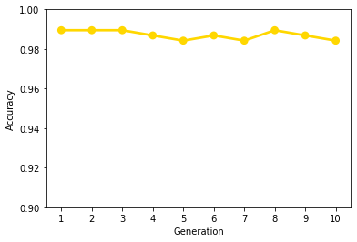

```python
plot(best_scores,0.9,1.0,c = "gold")
```

Berikut ini adalah fitur-fitur yang terpilih pada kromosom terbaik di setiap generasi:

```python
show_chromosomes(chromosomes)
```

[output not shown]

Dibawah ini adalah kromosom terbaik yang didapat dari model ini, dimana kromosom terbaik adalah kromosom yang memiliki tingkat akurasi tertinggi dan jumlah fitur terendah.

```python
best_chromosome = get_best_chromo(chromosomes, best_scores)
show_chromosome(best_chromosome)
```

```
Features:
radius_mean, texture_mean, smoothness_mean, compactness_mean, concavity_mean, concave points_mean, symmetry_mean, radius_se, texture_se, compactness_se, concave points_se, symmetry_se, perimeter_worst, area_worst, compactness_worst, concave points_worst, symmetry_worst
Total: 17 features
```

## 7. Evaluasi Neural Network

Algoritma *gradien descent* tersebut telah selesai. Sebelum melanjutkan, harus dipastikan bahwa algoritma telah dikodekan dengan benar, dan berperilaku seperti yang diharapkan. Ingatlah bahwa nilai fungsi biaya telah disimpan dalam sebuah array pada tahap sebelumnya. Array tersebut akan digunakan untuk memvalidasi bahwa algoritma telah memiliki perilaku yang tepat.

Jika algoritma telah berfungsi sebagaimana dimaksud, akan dilihat bahwa fungsi biaya secara umum akan menurun pada setiap iterasi hingga menjadi rata. Selain itu, kita harus melihat fungsi biaya kita pada akhirnya menjadi rata. Dengan menggunakan dataset untuk validasi silang dan tingkat pembelajaran (*learning rate*) sebesar 0,5, ditampilkan grafik nilai *cost function* yang dibandingkan dengan jumlah iterasi.

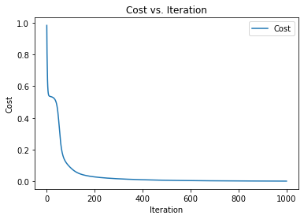

```python
W1,W2,W3,b1,b2,b3,count,caches = gradient_descent(1000,X_test,Y_test,0.5)

plt.plot(count,caches,label='Cost')

plt.xlabel('Iteration')
plt.ylabel('Cost')

plt.title("Cost vs. Iteration")
plt.legend()
plt.show()
```

Kemudian, sebelum melakukan evaluasi dengan dataset training dan test, kedua dataset tersebut akan diupdate berdasarkan fitur-fitur dari kromosom terbaik yang sebelumnya telah diseleksi.

```python
opt_X_train = X_train[best_chromosome]
opt_X_test = X_test[best_chromosome]
```

### Dataset Training

Dapatkan hasil prediksi dari dataset training

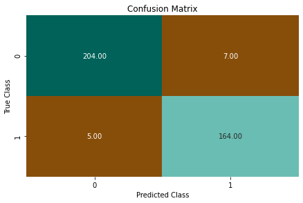

```python
train_predict = predict(opt_X_train,Y_train,1000,0.5,opt_X_train,Y_train)

plot_confusion_matrix(Y_train[0], train_predict[0])
```

Berdasarkan prediksi tersebut, didapatkan *confusion matrix* seperti berikut, dimana "M" bernilai 1 dan "B" bernilai 0.

```
Sensitivity or TPR       :  97.0414201183432 %
Specificity or TNR       :  96.6824644549763 %
Precision                :  95.90643274853801 %
Negative Predictive Value:  97.60765550239235 %
False Positive Rate      :  3.3175355450236967 %
False Negative Rate      :  2.9585798816568047 %
False Discovery Rate     :  4.093567251461988 %
Accuracy                 :  96.84210526315789 %
AUC                      :  0.9686194228665975
Figure(432x288)
```

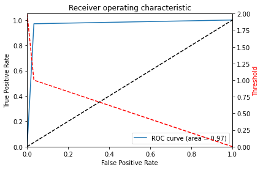

```python
plot_roc(Y_train[0], train_predict[0])
```

### Dataset Validasi Silang

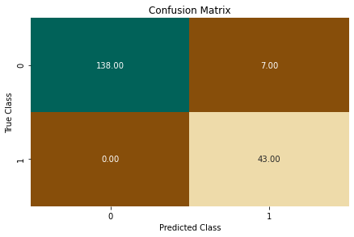

```python
test_predict = predict(opt_X_test,Y_test,1000,0.5,opt_X_train,Y_train)

plot_confusion_matrix(Y_test[0], test_predict[0])
```

```
Sensitivity or TPR       :  100.0 %
Specificity or TNR       :  95.17241379310344 %
Precision                :  86.0 %
Negative Predictive Value:  100.0 %
False Positive Rate      :  4.827586206896552 %
False Negative Rate      :  0.0 %
False Discovery Rate     :  14.000000000000002 %
Accuracy                 :  96.27659574468085 %
AUC                      :  0.9758620689655173
Figure(432x288)
```

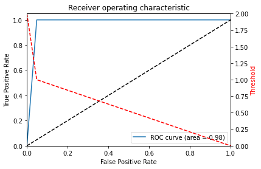

```python
plot_roc(Y_test[0], test_predict[0])
```

Berdasarkan statistik dari dua dataset di atas, bisa disimpulkan bahwa *neural network* ini dapat memprediksi tumor ganas ataupun jinak dengan akurat.